# Projekt 5

Anna Wójcik, Dawid Dąbkowski, Grzegorz Ziajka

19 maja 2017

# 1 Podsumowanie

W tym etapie zbadaliśmy interakcje między zmiennymi kraj i płeć oraz indeks podręcznika i płeć. Okazało się, że obie interakcje występują i są statystycznie istotne. W kolejnych etapach będziemy rozważać zatem model powiększony o te interakcje.

# 2 Przygotowanie danych

```r
library("forcats")
library("tidyr")
library("lmtest")
library("MASS")
library("ggplot2")
library("dplyr")
library("plyr")
```

```r
load("C:/Users/Anna/Downloads/actionTimeScoreGender.rda") # dane o zadaniach z matematyki plus plec

actionTimeScoreGender <- separate(actionTimeScoreGender, item_short, into = c('M', 'Q'), sep = 4)

actionTimeScoreGender$M <- as.factor(actionTimeScoreGender$M)
actionTimeScoreGender$Q <- as.factor(actionTimeScoreGender$Q)
actionTimeScoreGender$position <- replace(actionTimeScoreGender$position, actionTimeScoreGender$position==-1, NA)
actionTimeScoreGender$position <- droplevels(actionTimeScoreGender$position)

indeksy <- quantile(actionTimeScoreGender$T, probs=c(0.01, 0.99))
actionTimeScoreGender <- filter(actionTimeScoreGender, T <= indeksy[2])
actionTimeScoreGender <- filter(actionTimeScoreGender, T >= indeksy[1])

actionTimeScoreGender <- actionTimeScoreGender[complete.cases(actionTimeScoreGender),]

actionTimeScoreGenderSample <- sample_n(actionTimeScoreGender, 500000)
```

# 3 Przypomnienie wyjściowego modelu

Będziemy badać ewentualne występowanie interakcji między zmiennymi objaśniającymi przygotowanego w poprzednich etapach modelu m1.

```r
m1=lm(sqrt(T) ~ CNT + ST004D01T + BOOKID + position + M/Q, data = actionTimeScoreGenderSample)
```

# 4 Wykres interakcji między krajem a płcią

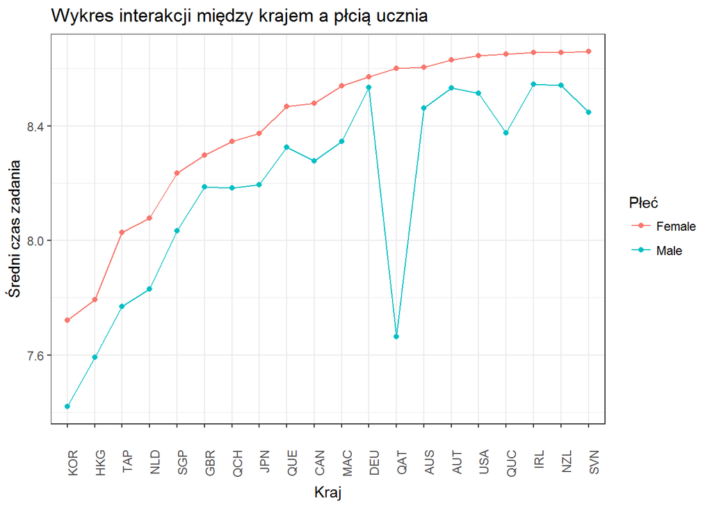

```r
actionTimeScoreGenderFemale<- filter(actionTimeScoreGender, actionTimeScoreGender$ST004D01T %in% "Female")
a<-ddply(actionTimeScoreGenderFemale, .(CNT), summarize, time=mean(sqrt(T)))

b <- a[order(a$time),]
chr=as.character(b$CNT)
new <- filter(actionTimeScoreGender, actionTimeScoreGender$CNT %in% b$CNT[1:20])
tst <- ddply(new,.(CNT,ST004D01T),summarise, time = mean(sqrt(T)))

p=ggplot(new, aes(x = fct_relevel(CNT,chr), y = sqrt(T), colour = ST004D01T)) +
    geom_point(data = tst, aes(y = time)) +
    geom_line(data = tst, aes(y = time, group = ST004D01T)) +
    theme_bw()+theme(axis.text.x = element_text(angle = 90, hjust = 1))+
    xlab("Kraj")+
    ylab("Średni czas zadania")+
    ggtitle("Wykres interakcji między krajem a płcią ucznia ")+ scale_colour_discrete(name="Płeć")

print(p)
```

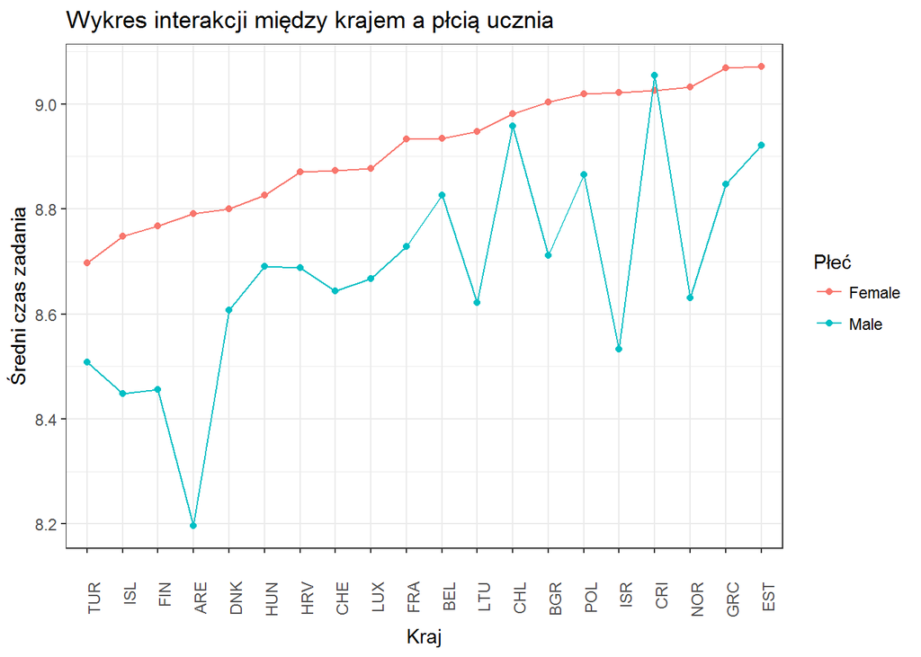

```r
new <- filter(actionTimeScoreGender, actionTimeScoreGender$CNT %in% b$CNT[21:40])
tst <- ddply(new,.(CNT,ST004D01T),summarise, time = mean(sqrt(T)))

p=ggplot(new, aes(x = fct_relevel(CNT,chr), y = sqrt(T), colour = ST004D01T)) +
    geom_point(data = tst, aes(y = time)) +
    geom_line(data = tst, aes(y = time, group = ST004D01T)) +
    theme_bw()+theme(axis.text.x = element_text(angle = 90, hjust = 1))+
    xlab("Kraj")+
    ylab("Średni czas zadania")+
    ggtitle("Wykres interakcji między krajem a płcią ucznia ")+ scale_colour_discrete(name="Płeć")

print(p)
```

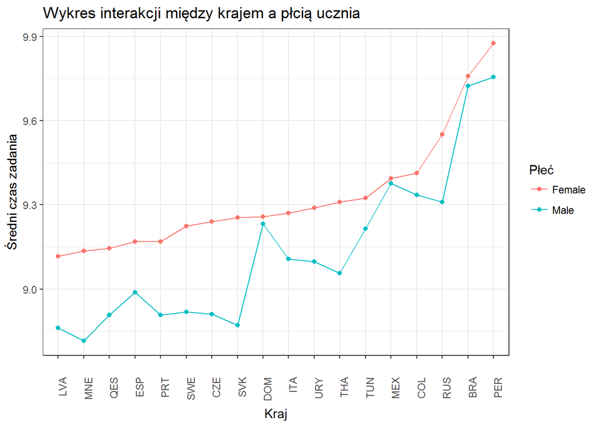

```r
new <- filter(actionTimeScoreGender, actionTimeScoreGender$CNT %in% b$CNT[41:58])
tst <- ddply(new,.(CNT,ST004D01T),summarise, time = mean(sqrt(T)))

p=ggplot(new, aes(x = fct_relevel(CNT,chr), y = sqrt(T), colour = ST004D01T)) +
    geom_point(data = tst, aes(y = time)) +
    geom_line(data = tst, aes(y = time, group = ST004D01T)) +
    theme_bw()+theme(axis.text.x = element_text(angle = 90, hjust = 1))+
    xlab("Kraj")+
    ylab("Średni czas zadania")+
    ggtitle("Wykres interakcji między krajem a płcią ucznia ")+ scale_colour_discrete(name="Płeć")

print(p)
```

Po przyjrzeniu się powyższym wykresom możemy podejrzewać, że interakcje mogą być istotne w tym modelu. Widzimy, że różnice w średnich czasach rozwiązania zadania przez kobiety i przez mężczyzn zależą od kraju pochodzenia, co prowadzi do braku równoległości na wykresie. Dla wielu krajów różnice te są niewielkie, np. BRA, CHL, DEU, dla innych są bardzo duże, np. ARE, QAT, ISR.

# 5 Wykres interakcji między indeksem podręcznika a płcią

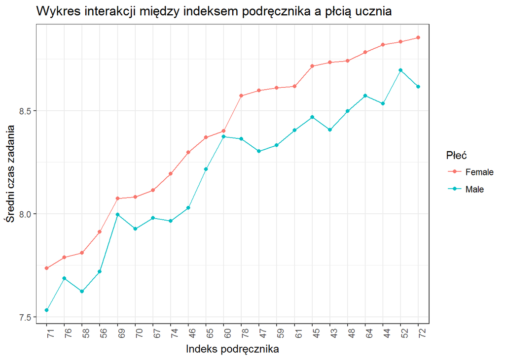

```r
actionTimeScoreGenderFemale<- filter(actionTimeScoreGender, actionTimeScoreGender$ST004D01T %in% "Female")
a<-ddply(actionTimeScoreGenderFemale, .(BOOKID), summarize, time=mean(sqrt(T)))

b <- a[order(a$time),]
chr=as.character(b$BOOKID)
new <- filter(actionTimeScoreGender, actionTimeScoreGender$BOOKID %in% b$BOOKID[1:22])
tst <- ddply(new,.(BOOKID,ST004D01T),summarise, time = mean(sqrt(T)))

p=ggplot(new, aes(x = fct_relevel(BOOKID,chr), y = sqrt(T), colour = ST004D01T)) +
    geom_point(data = tst, aes(y = time)) +
    geom_line(data = tst, aes(y = time, group = ST004D01T)) +
    theme_bw()+theme(axis.text.x = element_text(angle = 90, hjust = 1))+
    xlab("Indeks podręcznika")+
    ylab("Średni czas zadania")+
    ggtitle("Wykres interakcji między indeksem podręcznika a płcią ucznia ")+ scale_colour_discrete(name="Płeć")
print(p)
```

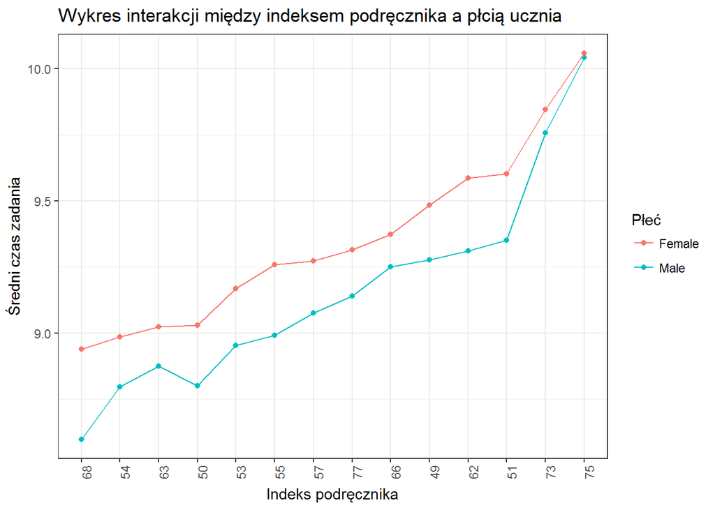

```r
new <- filter(actionTimeScoreGender, actionTimeScoreGender$BOOKID %in% b$BOOKID[23:44])
tst <- ddply(new,.(BOOKID,ST004D01T),summarise, time = mean(sqrt(T)))

p=ggplot(new, aes(x = fct_relevel(BOOKID,chr), y = sqrt(T), colour = ST004D01T)) +
    geom_point(data = tst, aes(y = time)) +
    geom_line(data = tst, aes(y = time, group = ST004D01T)) +
    theme_bw()+theme(axis.text.x = element_text(angle = 90, hjust = 1))+
    xlab("Indeks podręcznika")+
    ylab("Średni czas zadania")+
    ggtitle("Wykres interakcji między indeksem podręcznika a płcią ucznia ")+ scale_colour_discrete(name="Płeć")
print(p)
```

Tak jak w poprzednim przypadku możemy podejrzewać, że i ta interakcja może być istotne. Widzimy, że różnice w średnich czasach rozwiązania zadania przez kobiety i przez mężczyzn zależą od indeksu podręcznika, co prowadzi do braku równoległości na wykresie. Dla podręczników o numerach 43, 44, 45 różnice te są dość duże, a dla podręcznikóW 73, 75, 76 praktycznie niezauważalne.

# 6 Analiza wariancji modelu z interakcją między krajem a płcią

Użyjemy teraz funkcji anova, żeby sprawdzić istotność interakcji między krajem a płcią.

```r
anova(lm(sqrt(T) ~ ST004D01T*CNT, data = actionTimeScoreGenderSample))
```

```
## Analysis of Variance Table
##
## Response: sqrt(T)
##                   Df  Sum Sq Mean Sq F value    Pr(>F)
## ST004D01T          1    6307  6307.5 768.872 < 2.2e-16 ***
## CNT               57  108887  1910.3 232.863 < 2.2e-16 ***
## ST004D01T:CNT     57    4650    81.6   9.944 < 2.2e-16 ***
## Residuals     499884 4100817     8.2
## ---
## Signif. codes:  0 '***' 0.001 '**' 0.01 '*' 0.05 '.' 0.1 ' ' 1
```

```r
anova(lm(sqrt(T) ~ CNT*ST004D01T, data = actionTimeScoreGenderSample))
```

```
## Analysis of Variance Table
##
## Response: sqrt(T)
##                   Df  Sum Sq Mean Sq F value    Pr(>F)
## CNT               57  109274  1917.1 233.691 < 2.2e-16 ***
## ST004D01T          1    5920  5920.1 721.655 < 2.2e-16 ***
## CNT:ST004D01T     57    4650    81.6   9.944 < 2.2e-16 ***
## Residuals     499884 4100817     8.2
## ---
## Signif. codes:  0 '***' 0.001 '**' 0.01 '*' 0.05 '.' 0.1 ' ' 1
```

Analiza wariancji potwierdza nasze przypuszczenia. Interakcja ST004D01T:CNT jest istotna na poziomie niższym niż 2.2e-16.

# 7 Analiza wariancji modelu z interakcją między indeksem podręcznika a płcią

Użyjemy teraz funkcji anova, żeby sprawdzić istotność interakcji między indeksem podręcznika a płcią.

```r
anova(lm(sqrt(T) ~ ST004D01T*BOOKID, data = actionTimeScoreGenderSample))
```

```
## Analysis of Variance Table
##
## Response: sqrt(T)
##                      Df  Sum Sq Mean Sq  F value    Pr(>F)
## ST004D01T             1    6307  6307.5 762.8658 < 2.2e-16 ***
## BOOKID               35   80347  2295.6 277.6482 < 2.2e-16 ***
## ST004D01T:BOOKID     35     540    15.4   1.8677  0.001389 **
## Residuals        499928 4133467     8.3
## ---
## Signif. codes:  0 '***' 0.001 '**' 0.01 '*' 0.05 '.' 0.1 ' ' 1
```

```r
anova(lm(sqrt(T) ~ BOOKID*ST004D01T, data = actionTimeScoreGenderSample))
```

```
## Analysis of Variance Table
##
## Response: sqrt(T)
##                      Df  Sum Sq Mean Sq  F value    Pr(>F)
## BOOKID               35   80295  2294.1 277.4688 < 2.2e-16 ***
## ST004D01T             1    6359  6359.4 769.1450 < 2.2e-16 ***
## BOOKID:ST004D01T     35     540    15.4   1.8677  0.001389 **
## Residuals        499928 4133467     8.3
## ---
## Signif. codes:  0 '***' 0.001 '**' 0.01 '*' 0.05 '.' 0.1 ' ' 1
```

Tym razem analiza wariancji również potwierdza istotność interakcji ST004D01T:BOOKID.

# 8 Analiza wariancji ostatecznego modelu

Sprawdźmy teraz model, który zawiera obie z analizowanych przez nas interakcji.

```r
anova(lm(sqrt(T) ~ ST004D01T*CNT+ST004D01T*BOOKID, data = actionTimeScoreGenderSample))
```

```
## Analysis of Variance Table
##
## Response: sqrt(T)
##                      Df  Sum Sq Mean Sq  F value    Pr(>F)
## ST004D01T             1    6307  6307.5 784.3075 < 2.2e-16 ***
## CNT                  57  108887  1910.3 237.5377 < 2.2e-16 ***
## BOOKID               35   80835  2309.6 287.1851 < 2.2e-16 ***
## ST004D01T:CNT        57    4608    80.8  10.0525 < 2.2e-16 ***
## ST004D01T:BOOKID     35     476    13.6   1.6926  0.006409 **
## Residuals        499814 4019548     8.0
## ---
## Signif. codes:  0 '***' 0.001 '**' 0.01 '*' 0.05 '.' 0.1 ' ' 1
```

```r
anova(lm(sqrt(T) ~ ST004D01T*BOOKID+ST004D01T*CNT, data = actionTimeScoreGenderSample))
```

```
## Analysis of Variance Table
##
## Response: sqrt(T)
##                      Df  Sum Sq Mean Sq  F value    Pr(>F)
## ST004D01T             1    6307  6307.5 784.3075 < 2.2e-16 ***
## BOOKID               35   80347  2295.6 285.4520 < 2.2e-16 ***
## CNT                  57  109375  1918.9 238.6019 < 2.2e-16 ***
## ST004D01T:BOOKID     35     473    13.5   1.6803  0.007102 **
## ST004D01T:CNT        57    4612    80.9  10.0601 < 2.2e-16 ***
## Residuals        499814 4019548     8.0
## ---
## Signif. codes:  0 '***' 0.001 '**' 0.01 '*' 0.05 '.' 0.1 ' ' 1
```

Obie interkacje wydają się być istotne, więc skłaniamy się ku wyborowi modelu, który poza dotychczasowymi składnikami będzie zawierał jeszcze interakcje między krajem a płcią oraz indeksem podręcznika i płcią.

# 9 Porównanie modeli

```r
model01=lm(sqrt(T) ~position + M/Q+CNT+ST004D01T*BOOKID, data = actionTimeScoreGenderSample)
```

```r
model02=lm(sqrt(T) ~position + M/Q+CNT+ST004D01T*CNT+BOOKID, data = actionTimeScoreGenderSample)
```

```r
model1=lm(sqrt(T) ~position + M/Q+ST004D01T*CNT+ST004D01T*BOOKID, data = actionTimeScoreGenderSample)
```

Porównajmy jeszcze ze sobą analizowane modele i sprawdźmy czy dodanie interakcji istotnie poprawia model.

```r
anova(m1,model01)
```

```
## Analysis of Variance Table
##
## Model 1: sqrt(T) ~ CNT + ST004D01T + BOOKID + position + M/Q
## Model 2: sqrt(T) ~ position + M/Q + CNT + ST004D01T * BOOKID
##   Res.Df     RSS Df Sum of Sq      F   Pr(>F)
## 1 499845 3296915
## 2 499810 3296456 35    459.33 1.9898 0.000443 ***
## ---
## Signif. codes:  0 '***' 0.001 '**' 0.01 '*' 0.05 '.' 0.1 ' ' 1
```

```r
anova(m1,model02)
```

```
## Analysis of Variance Table
##
## Model 1: sqrt(T) ~ CNT + ST004D01T + BOOKID + position + M/Q
## Model 2: sqrt(T) ~ position + M/Q + CNT + ST004D01T * CNT + BOOKID
##   Res.Df     RSS Df Sum of Sq      F    Pr(>F)
## 1 499845 3296915
## 2 499788 3292478 57    4437.8 11.818 < 2.2e-16 ***
## ---
## Signif. codes:  0 '***' 0.001 '**' 0.01 '*' 0.05 '.' 0.1 ' ' 1
```

```r
anova(model01,model1)
```

```
## Analysis of Variance Table
##
## Model 1: sqrt(T) ~ position + M/Q + CNT + ST004D01T * BOOKID
## Model 2: sqrt(T) ~ position + M/Q + ST004D01T * CNT + ST004D01T * BOOKID
##   Res.Df     RSS Df Sum of Sq      F    Pr(>F)
## 1 499810 3296456
## 2 499753 3292013 57    4443.2 11.834 < 2.2e-16 ***
## ---
## Signif. codes:  0 '***' 0.001 '**' 0.01 '*' 0.05 '.' 0.1 ' ' 1
```

```r
anova(model02,model1)
```

```
## Analysis of Variance Table
##
## Model 1: sqrt(T) ~ position + M/Q + CNT + ST004D01T * CNT + BOOKID
## Model 2: sqrt(T) ~ position + M/Q + ST004D01T * CNT + ST004D01T * BOOKID
##   Res.Df     RSS Df Sum of Sq      F    Pr(>F)
## 1 499788 3292478
## 2 499753 3292013 35    464.72 2.0157 0.0003453 ***
## ---
## Signif. codes:  0 '***' 0.001 '**' 0.01 '*' 0.05 '.' 0.1 ' ' 1
```

```r
anova(m1,model1)
```

```
## Analysis of Variance Table
##
## Model 1: sqrt(T) ~ CNT + ST004D01T + BOOKID + position + M/Q
## Model 2: sqrt(T) ~ position + M/Q + ST004D01T * CNT + ST004D01T * BOOKID
##   Res.Df     RSS Df Sum of Sq      F    Pr(>F)
## 1 499845 3296915
## 2 499753 3292013 92    4902.6 8.0897 < 2.2e-16 ***
## ---
## Signif. codes:  0 '***' 0.001 '**' 0.01 '*' 0.05 '.' 0.1 ' ' 1
```

Modele z jedną z wybranych interakcji są istotnie lepsze od modelu m1 bez interakcji. Model z dwoma interakcjami jest istotnie lepszy od tego z tylko jedną interakcją, więc wybieramy model1 do dalszych analiz.